# Quiz 1 Bonus Materials

Thomas E. Love

due at noon Monday 2018-03-26. Version 2018-03-26

```r
library(rms)
library(arm)
library(broom)
library(leaps)
library(tidyverse)
```

# 1 Question 1

## 1.1 Setup

```r
set.seed(4321)
time <- c(rnorm(30, 110, 20), rnorm(30, 115, 18), rnorm(30, 130, 22), rnorm(30, 100, 24))
treat <- c(rep(1, 30), rep(2, 30), rep(3, 30), rep(0, 30))
order <- c(runif(120, 0, 1))

dat01 <- data_frame(subject = round(10000*order, 0),
                    time_to_repair = round(time,0),
                    treat = treat)

dat01 <- dat01 %>% arrange(subject)

write_csv(dat01, "dat01.csv")

rm(time, treat, order)

dat01
```

```
# A tibble: 120 x 3
   subject time_to_repair treat
     <dbl>          <dbl> <dbl>
 1     38.           131.    3.
 2    120.           137.    0.
 3    153.           111.    1.
 4    278.           101.    2.
 5    294.           130.    2.
 6    296.           127.    3.
 7    383.           136.    2.
 8    442.           134.    0.
 9    525.           101.    1.
10    562.           131.    3.
# ... with 110 more rows
```

```r
dat01 <- read.csv("dat01.csv") %>% tbl_df %>%
    mutate(treatment = fct_recode(factor(treat),
                                  A1 = "1", A2 = "2",
                                  B = "3", UC = "0"),
           treatment = fct_relevel(treatment, "A1", "A2", "B"))
```

## 1.2 The Question

Questions 1-5 involve data from a randomized controlled trial compares four potential treatments for the repair of a valve. You will find a copy of the data in the `dat01.csv` file. The data set includes a variable called `treat` which contains the values 0, 1, 2, 3, and which needs to be recoded as a factor in R. Provide the code to import the `dat01.csv` file into a tibble called `dat01` in R, and then create a factor within `dat01` named `treatment` that has the following properties:

1. `treat` = 0 refers to `treatment` = UC
2. `treat` = 1 is captured as `treatment` = A1
3. `treat` = 2 refers to `treatment` = A2
4. `treat` = 3 refers to `treatment` = B
5. the factor `treatment` is ordered A1, A2, B, UC.

You will know you have completed the task successfully when you obtain the following output:

```r
dat01 %>% count(treatment)
```

```
# A tibble: 4 x 2
  treatment     n
  <fct>     <int>
1 A1           30
2 A2           30
3 B            30
4 UC           30
```

## 1.3 Answer 1 (5 points)

```r
dat01 <- read.csv("dat01.csv") %>% tbl_df %>%
    mutate(treatment = fct_recode(factor(treat),
                                  A1 = "1", A2 = "2",
                                  B = "3", UC = "0"),
           treatment = fct_relevel(treatment, "A1", "A2", "B"))
```

# 2 Question 2

## 2.1 The Target Plot for Question 2

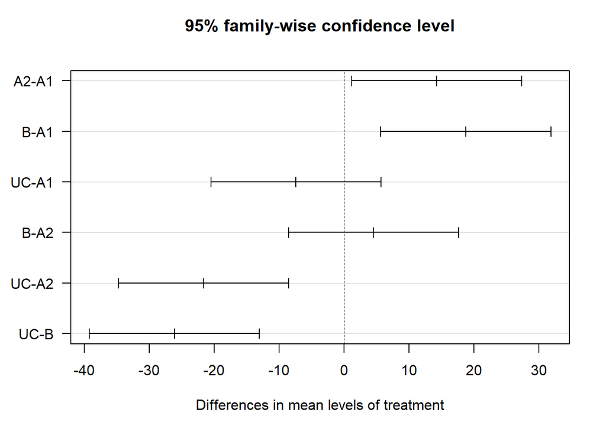

```r
plot(TukeyHSD(
    aov(time_to_repair ~ treatment, data = dat01)),
    las = 1)
```

## 2.2 The question

Question 2 involves the results of a randomized controlled trial comparing four potential treatments for the repair of a valve, which in question 1 you labeled as A1, A2, B and UC. The outcome of interest is `time_to_repair` = survival time before another repair of the same valve is required, which we’d like to be as large as possible. A1 and A2 are two versions of the “A” approach, “B” is a separate approach, and “UC” describes the standard approach (or “usual care”.) Your job is to use the data provided to you to produce the Target Plot shown above, which describes the results of Tukey’s HSD comparison, with a 95% confidence level. Your response should include the code to produce the Tukey HSD plot, working from the data frame you developed in Question 1. Thus, your response to Question 2 can be accomplished in a single line of R code. Note: to get the labels to show up on the y axis in this fashion rather than flipped 90 degrees, you’ll have to add the command `las = 1` to your plot.

## 2.3 Answer 2 (5 points)

`plot(TukeyHSD(aov(time_to_repair ~ treatment, data = dat01)), las = 1)`

accomplishes the task.

# 3 Question 3

## 3.1 The question

Refer to the Target Plot from Question 2 and describe, in complete English sentences, the pairwise comparisons of the four potential treatments. What conclusions can you draw, in terms of statistical significance? Don’t forget to clearly indicate for each comparison whether one treatment appears to perform better or worse than another in terms of time to repair.

## 3.2 Answer 3 (10 points)

At a 5% family-wise significance level:

- The mean time to repair for approaches B and A2 looks significantly better (longer) than A1 and also significantly better than Usual Care.
- The mean time to repair for approaches B and A2 do not appear to be statistically significantly different. Nor do approaches A1 and Usual Care.

# 4 Question 4

## 4.1 Setup

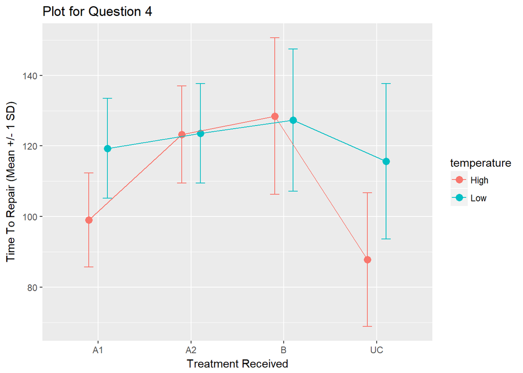

```r
dat04 <- read.csv("dat04.csv") %>% tbl_df

dat_0104 <- left_join(dat01, dat04)

#interaction.plot(dat_final$treatment,
#                 dat_final$temperature,
#                 dat_final$time_to_repair)

dat_finalsum <- dat_0104 %>%
    group_by(treatment, temperature) %>%
    summarize(mean.time = mean(time_to_repair),
              sd.time = sd(time_to_repair))
pd <- position_dodge(0.4)

ggplot(dat_finalsum, aes(x = treatment,
                         y = mean.time,
                         col = temperature)) +
    geom_errorbar(aes(ymin = mean.time - sd.time,
                      ymax = mean.time + sd.time),
                  width = 0.2, position = pd) +
    geom_point(size = 3, position = pd) +
    geom_line(aes(group = temperature), position = pd) +
    labs(y = "Time To Repair (Mean +/- 1 SD)",
         x = "Treatment Received",
         title = "Plot for Question 4")
```

The `dat04.csv` data file specifies the subjects (that we have been studying in Questions 1-3) as well as their temperature (High or Low) at the time of the valve repair. I merged those data with the data in my `dat01` data frame to produce the plot above. In a few sentences, describe what this plot tells you about the relationships between time to repair and the treatment received and the temperature. In particular, what does this plot tell you about how to fit an analysis of variance model?

## 4.2 Answer 4 (5 points)

Because the lines are nowhere near parallel that join the group means by temperature, the plot tells you that there is a meaningful interaction between temperature and treatment on time to repair, and so our ANOVA should include that interaction term.

# 5 Question 5

Merge together the `dat01` data frame you’ve developed through Questions 1-3 with this new `temperature` information from Question 4. Hint: import the `dat04` data as a tibble then use the `left_join` command to merge the two tibbles you have (`dat01` and `dat04`) into one. Next, obtain an appropriate two-way analysis of variance evaluating the impact of treatment and temperature on time. There are two possible two-way ANOVA models you could fit, one with interaction and one without. Display the ANOVA table for the model you select, specify why you chose that model, and then specify the conclusions of that table in English sentences.

## 5.1 Answer 5 (10 points)

The ANOVA table you need will incorporates the product term.

```r
anova(lm(time_to_repair ~ treatment * temperature,
         data = dat_0104))
```

```
Analysis of Variance Table

Response: time_to_repair
                       Df Sum Sq Mean Sq F value    Pr(>F)
treatment               3  13374  4457.9 14.2463 6.286e-08 ***
temperature             1   4201  4200.8 13.4247  0.000381 ***
treatment:temperature   3   4734  1578.1  5.0432  0.002579 **
Residuals             112  35047   312.9
---
Signif. codes:  0 '***' 0.001 '**' 0.01 '*' 0.05 '.' 0.1 ' ' 1
```

The fundamental conclusion is that the treatment:temperature interaction is significant and strong. The differences between the `treatment` effects on mean `time_to_repair` change depending on `temperature`.

# 6 Question 6

The `dat06.csv` data set contains information on 800 observations of an outcome variable, `y`, and nine predictors, labeled `x1` through `x9`, plus a `sample` variable, which takes the value “development” for 600 observations and the value “testing” for the remaining 200 observations.

The four plots and the table below were obtained by running a “best subsets” procedure to identify models from the complete set of available predictors (the `x`s) to predict `y`, but including only the data in `dat06` in the “development” `sample`.

```r
set.seed(43216)
x1 <- rnorm(800, mean = 200, sd = 50)
x2 <- rnorm(800, mean = 200, sd = 50) + 3*(x1 - 600)/7
x3 <- rnorm(800, mean = 20, sd = 5)
x4 <- rnorm(800, mean = 30, sd = 5)
x5 <- rpois(800, lambda = 5)
x6 <- rpois(800, lambda = 12)
x7 <- rbernoulli(800, p = 0.4)
x8 <- rnorm(800, mean = 20, sd = 4)
x9 <- rnorm(800, mean = 100, sd = 25)
err <- rnorm(800, mean = 0, sd = 24)
y <- 5*(x1-200)/50 - 2*(x2-200)/50 + 6*(x6-12)/12 - 4*(x9-100)/25 + 4*x7 + err
sample <- c(rep("development", 600), rep("testing", 200))

dat06 <- data_frame(subject = 1:800,
                    y, x1, x2, x3, x4, x5, x6, x7, x8, x9, sample)

write_csv(dat06, "dat06.csv")

rm(x1, x2, x3, x4, x5, x6, x7, x8, x9, err, y, sample)
```

```r
dat06_dev <- dat06 %>% filter(sample == "development")
dat06_test <- dat06 %>% filter(sample == "testing")

preds <- with(dat06_dev,
              cbind(x1, x2, x3, x4, x5, x6, x7, x8, x9))
set <- regsubsets(preds, dat06_dev$y, nvmax = 10)
rs <- summary(set)
```

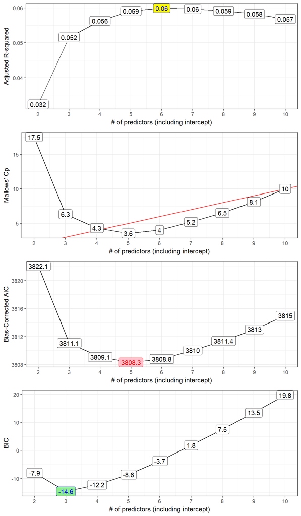

```r
rs$aic.c <- 600*log(rs$rss / 600) + 2*(2:10) +
               (2 * (2:10) * ((2:10)+1) / (600 - (2:10) - 1))

best_mods_1 <- data_frame(
    k = 2:10,
    r2 = rs$rsq,
    adjr2 = rs$adjr2,
    cp = rs$cp,
    aic.c = rs$aic.c,
    bic = rs$bic
)

best_mods <- cbind(best_mods_1, rs$which)

p1 <- ggplot(best_mods, aes(x = k, y = adjr2,
                            label = round(adjr2,3))) +
    geom_line() +
    geom_label() +
    geom_label(data = subset(best_mods,
                             adjr2 == max(adjr2)),
               aes(x = k, y = adjr2, label = round(adjr2,3)),
               fill = "yellow", col = "blue") +
    theme_bw() +
    scale_x_continuous(breaks = 2:10) +
    labs(x = "# of predictors (including intercept)",
         y = "Adjusted R-squared")

p2 <- ggplot(best_mods, aes(x = k, y = cp,
                            label = round(cp,1))) +
    geom_line() +
    geom_abline(intercept = 0, slope = 1,
                col = "red") +
    geom_label() +
    theme_bw() +
    scale_x_continuous(breaks = 2:10) +
    labs(x = "# of predictors (including intercept)",
         y = "Mallows' Cp")

p3 <- ggplot(best_mods, aes(x = k, y = aic.c,
                             label = round(aic.c,1))) +
    geom_line() +
    geom_label() +
    geom_label(data = subset(best_mods, aic.c == min(aic.c)),
               aes(x = k, y = aic.c), fill = "pink",
               col = "red") +
    theme_bw() +
    scale_x_continuous(breaks = 2:10) +
    labs(x = "# of predictors (including intercept)",
         y = "Bias-Corrected AIC")

p4 <- ggplot(best_mods, aes(x = k, y = bic,
                            label = round(bic,1))) +
    geom_line() +
    geom_label() +
    geom_label(data = subset(best_mods, bic == min(bic)),
               aes(x = k, y = bic),
               fill = "lightgreen", col = "blue") +
    theme_bw() +
    scale_x_continuous(breaks = 2:10) +
    labs(x = "# of predictors (including intercept)",
         y = "BIC")

gridExtra::grid.arrange(p1, p2, p3, p4, nrow = 4)
```

```r
rs$which
```

```
  (Intercept)    x1    x2    x3    x4    x5    x6    x7    x8   x9
1        TRUE FALSE FALSE FALSE FALSE FALSE FALSE FALSE FALSE TRUE
2        TRUE  TRUE FALSE FALSE FALSE FALSE FALSE FALSE FALSE TRUE
3        TRUE  TRUE FALSE FALSE  TRUE FALSE FALSE FALSE FALSE TRUE
4        TRUE  TRUE FALSE FALSE  TRUE FALSE  TRUE FALSE FALSE TRUE
5        TRUE  TRUE  TRUE FALSE  TRUE FALSE  TRUE FALSE FALSE TRUE
6        TRUE  TRUE  TRUE FALSE  TRUE FALSE  TRUE FALSE  TRUE TRUE
7        TRUE  TRUE  TRUE FALSE  TRUE FALSE  TRUE  TRUE  TRUE TRUE
8        TRUE  TRUE  TRUE  TRUE  TRUE FALSE  TRUE  TRUE  TRUE TRUE
9        TRUE  TRUE  TRUE  TRUE  TRUE  TRUE  TRUE  TRUE  TRUE TRUE
```

Specify the models suggested by each of the four plots, by identifying the predictors included in those models. Be sure to indicate which plot specifies which candidate model clearly, and use the data in the “development” sample to specify the prediction equation obtained from least squares regression for each model. If two plots specify the same model, indicate that.

## 6.1 Answer 6 (10 points)

Those models are:

| Suggested By | # predictors | Predictor List |
| --- | --- | --- |
| BIC | 3 | Intercept, `x1`, `x9` |
| C<sub>p</sub> | 4 | Intercept, `x1`, `x4`, `x9` |
| AIC<sub>c</sub> | 5 | Intercept, `x1`, `x4`, `x6`, `x9` |
| adj R<sup>2</sup> | 6 | Intercept, `x1`, `x2`, `x4`, `x6`, `x9` |

# 7 Question 7

Fit the models suggested by each of the four plots within the “development” `sample` in Question 6, then use those models to make predictions for every value in the “testing” `sample`. Compare the four models in terms of their root mean squared prediction error and their mean absolute prediction error. Write a sentence or two to explain the results and pick a “winning” model.

## 7.1 Answer 7 (15 points)

First, we fit the four models in the development sample:

```r
m03 <- lm(y ~ x1 + x9, data = dat06_dev)
m04 <- lm(y ~ x1 + x4 + x9, data = dat06_dev)
m05 <- lm(y ~ x1 + x4 + x6 + x9, data = dat06_dev)
m06 <- lm(y ~ x1 + x2 + x4 + x6 + x9, data = dat06_dev)
```

Next, we use each model to predict the cases in the testing sample, and save the predictions and errors.

```r
pred03 <- predict(m03, newdata = dat06_test)
errors03 <- dat06_test$y - pred03

pred04 <- predict(m04, newdata = dat06_test)
errors04 <- dat06_test$y - pred04

pred05 <- predict(m05, newdata = dat06_test)
errors05 <- dat06_test$y - pred05

pred06 <- predict(m06, newdata = dat06_test)
errors06 <- dat06_test$y - pred06
```

Then, we calculate and compare the root mean squared errors and the mean absolute errors from each model.

```r
rmse03 <- sqrt(mean(errors03^2))
mae03 <- mean(abs(errors03))

rmse04 <- sqrt(mean(errors04^2))
mae04 <- mean(abs(errors04))

rmse05 <- sqrt(mean(errors05^2))
mae05 <- mean(abs(errors05))

rmse06 <- sqrt(mean(errors06^2))
mae06 <- mean(abs(errors06))
```

Here are the results:

| Model | RMSE | MAE |
| --- | --- | --- |
| 3 | 24.09 | 18.81 |
| 4 | 24.15 | 18.86 |
| 5 | 24.11 | 18.82 |
| 6 | 24.03 | 18.69 |

The results are pretty similar across the four models, but the model with 6 predictors (including the intercept) has slightly lower RMSE and mean absolute error, so it “wins.” That’s the model with `x1`, `x2`, `x4`, `x6` and `x9`.

# 8 Question 8

Fit the model that performed best in Question 7 to the full data set (all 800 observations.)

1. What is the percentage of variation in `y` accounted for by this model in these 800 observations?
2. Estimate the percentage of variation in `y` that will be accounted for by this model when applied to a new, similar data set. Show what you did to obtain this estimate.

## 8.1 Answer 8 (10 points, 5 points for each part)

### 8.1.1 Part 8a (5 points)

For part a, we just need to fit the model and obtain the R<sup>2</sup> value.

```r
d <- datadist(dat06)
options(datadist = "d")

(model_q8 <- ols(y ~ x1 + x2 + x4 + x6 + x9,
                data = dat06, x = TRUE, y = TRUE))
```

```
Linear Regression Model

 ols(formula = y ~ x1 + x2 + x4 + x6 + x9, data = dat06, x = TRUE,
     y = TRUE)

                 Model Likelihood     Discrimination
                    Ratio Test           Indexes
 Obs      800    LR chi2     56.87    R2       0.069
 sigma23.8224    d.f.            5    R2 adj   0.063
 d.f.     794    Pr(> chi2) 0.0000    g        7.254

 Residuals

    Min     1Q Median     3Q    Max
 -76.84 -15.87  -0.38  16.52  79.38


           Coef    S.E.   t     Pr(>|t|)
 Intercept -9.0208 7.6241 -1.18 0.2371
 x1         0.0987 0.0184  5.36 <0.0001
 x2        -0.0291 0.0168 -1.74 0.0826
 x4         0.3030 0.1640  1.85 0.0651
 x6         0.4459 0.2456  1.82 0.0698
 x9        -0.1485 0.0342 -4.35 <0.0001
```

So the answer to part **8a** is 0.069, or 6.9% of the variation in `y` is explained by this model.

### 8.1.2 Part 8b (5 points)

To answer part b, we need an index-corrected R<sup>2</sup> value as provided by `validate`. I’ll use the same seed I recommended you use in a later question in this assignment, `432432`.

```r
set.seed(432432)
validate(model_q8)
```

```
          index.orig training     test optimism index.corrected  n
R-square      0.0686   0.0712   0.0624   0.0088          0.0599 40
MSE         563.2506 558.9299 566.9954  -8.0655        571.3161 40
g             7.2538   7.3169   7.0493   0.2676          6.9862 40
Intercept     0.0000   0.0000   0.3184  -0.3184          0.3184 40
Slope         1.0000   1.0000   0.9796   0.0204          0.9796 40
```

So the answer to part **8b** is that the cross-validated R<sup>2</sup> value is 0.0599, or 5.99% of the variation. If you used a different seed, you’ll get a different answer, of course.

# 9 Question 9

Assess the regression assumptions of the model that you fit in Question 8. Show the usual four residual and diagnostic plots of the regression model after fitting it to the entire sample of 800 observations, and interpret the results.

## 9.1 Answer 9 (10 points)

To answer this, I’ll build the `lm` version of the model.

```r
model_q9 <- lm(y ~ x1 + x2 + x4 + x6 + x9, data = dat06)
```

Here is the set of four residual plots.

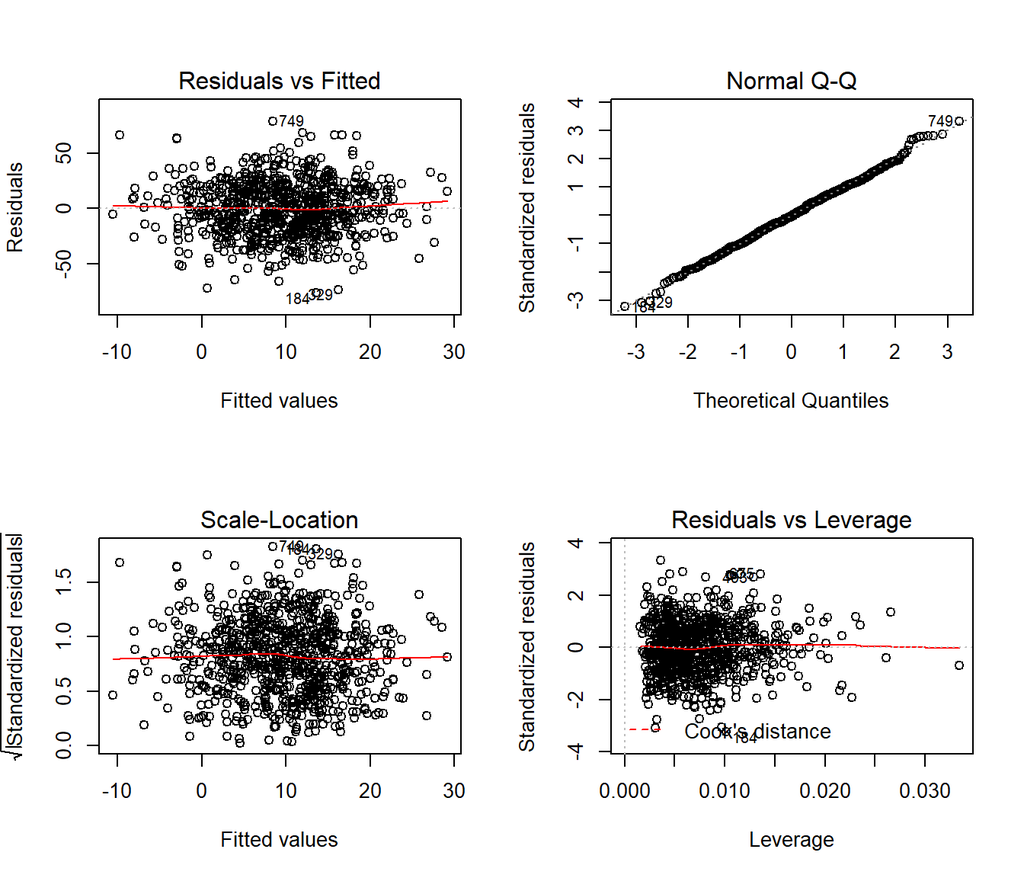

```r
par(mfrow = c(2,2))
plot(model_q9)
```

```r
par(mfrow = c(1,1))
```

I see no problems with assumption violations in this model.

- The residuals vs. fitted values looks like a random scatter, a “fuzzy football” with no apparent curve or fan shape.
- The residuals appear well-modeled by a Normal distribution in the Q-Q plot. There’s not much deviation from the diagonal line.
- The scale-location plot shows no particular signs of heteroscedasticity, as the square root of the standardized residuals seems to be distributed around a constant mean as we move from low to high fitted values.
- Finally, the residuals vs. leverage plot shows no particularly influential or highly-leveregaed points, nor do we see any residuals that are substantially larger than we’d expect with 800 observations.

# 10 Question 10

The data in the `dat10.csv` file contain information for 250 subjects on a binary `outcome` (Good or Bad), a `size` (quantitative, between 60 and 200), a logical indicator of whether a `treatment` was used (TRUE = treatment was used or FALSE = treatment was not used), and a specification as to which of five ordered groups (1 = lowest, 5 = highest) by socio-economic status (`ses_group`) the subject falls in, along with a subject ID.

Import the data into the `dat10` frame, and then fit a logistic regression model to predict the log odds of a Good `outcome` using the subject’s `size`, `treatment` status and `ses_group`, treating the `ses_group` as a categorical variable. For Questions 10 and 11, use a complete case analysis. A complete case analyses yields the results specified below.

```r
dat10 <- read.csv("dat10.csv") %>% tbl_df

dat10 <- dat10 %>%
    mutate(goodoutcome = ifelse(outcome == "Good", 1, 0))
```

**Note that the fitting of the actual `m1` is not shown.**

```r
m1 <- glm(goodoutcome ~ size + treatment + factor(ses_group), data = dat10, family = binomial)
```

```r
exp(coef(m1))
```

```
       (Intercept)               size      treatmentTRUE
         0.1585338          1.0090549          0.5728293
factor(ses_group)2 factor(ses_group)3 factor(ses_group)4
         1.3569411          1.4220772          1.2805544
factor(ses_group)5
         1.4752464
```

```r
exp(confint(m1))
```

```
                        2.5 %    97.5 %
(Intercept)        0.03042517 0.7635905
size               0.99754375 1.0209696
treatmentTRUE      0.32260266 1.0142938
factor(ses_group)2 0.42226765 4.4921913
factor(ses_group)3 0.52570487 4.1528045
factor(ses_group)4 0.43702393 3.9643440
factor(ses_group)5 0.56280890 4.2102848
```

1. Specify the code used to fit the `m1` model in this setting. Use the data to verify that your answer is correct.
2. Interpret the `treatmentTRUE` value of 0.573 specified in the output above, in a complete English sentence.
3. What does the confidence interval (0.323, 1.014) for `treatmentTRUE` tell you about the `treatment` variable? Why?

## 10.1 Answer 10 (15 points, 5 for each part)

### 10.1.1 Part 10a (5 points)

The code used was:

```r
(m1 <- glm(goodoutcome ~ size + treatment + factor(ses_group), data = dat10, family = binomial))
```

```
Call:  glm(formula = goodoutcome ~ size + treatment + factor(ses_group),
    family = binomial, data = dat10)

Coefficients:
       (Intercept)                size       treatmentTRUE
         -1.841787            0.009014           -0.557168
factor(ses_group)2  factor(ses_group)3  factor(ses_group)4
          0.305233            0.352119            0.247293
factor(ses_group)5
          0.388825

Degrees of Freedom: 231 Total (i.e. Null);  225 Residual
  (18 observations deleted due to missingness)
Null Deviance:      287.4
Residual Deviance: 279.9    AIC: 293.9
```

We can see from the output above that 18 observations were deleted due to missingness. Since we started with 250 subjects, this means that **232** observations were used to fit the model.

### 10.1.2 Part 10b (5 points)

If we have two subjects, with the same values of `size` and `ses_group`, but Harry receives the treatment and Sally does not, then this model predicts that Harry’s odds of a good outcome will be 57.3% of Sally’s odds.

### 10.1.3 Part 10c (5 points)

According to this confidence interval, the data are consistent with a `treatment` variable’s odds ratio of 1, as well as with many other values, so we cannot conclude that the `treatment` effect is statistically significant at the 5% level.

# 11 Question 11

The output below comes from another approach to fitting the identical logistic regression model that we saw in Question 10, still using only the complete cases. I’ll call this model m1L, to emphasize that it contains the same outcome and predictors, put together in the same way.

In this answer sketch, I’ll show you the full model.

```r
d <- datadist(dat10)
options(datadist = "d")

(m1L <- lrm(goodoutcome ~ size + treatment + catg(ses_group), data = dat10))
```

```
Frequencies of Missing Values Due to Each Variable
goodoutcome        size   treatment   ses_group
          0           5           3          11

Logistic Regression Model

 lrm(formula = goodoutcome ~ size + treatment + catg(ses_group),
     data = dat10)


                      Model Likelihood     Discrimination    Rank Discrim.
                         Ratio Test           Indexes           Indexes
 Obs           232    LR chi2      7.47    R2       0.045    C       0.608
  0            160    d.f.            6    g        0.456    Dxy     0.216
  1             72    Pr(> chi2) 0.2793    gr       1.578    gamma   0.216
 max |deriv| 4e-11                         gp       0.095    tau-a   0.093
                                           Brier    0.207

             Coef    S.E.   Wald Z Pr(>|Z|)
 Intercept   -1.8418 0.8183 -2.25  0.0244
 size         0.0090 0.0059  1.53  0.1264
 treatment   -0.5572 0.2915 -1.91  0.0560
 ses_group=2  0.3052 0.5963  0.51  0.6088
 ses_group=3  0.3521 0.5213  0.68  0.4994
 ses_group=4  0.2473 0.5564  0.44  0.6567
 ses_group=5  0.3888 0.5074  0.77  0.4435
```

```r
summary(m1L)
```

```
             Effects              Response : goodoutcome

 Factor          Low   High  Diff. Effect    S.E.    Lower 0.95 Upper 0.95
 size            100.5 135.5 35     0.315490 0.20642 -0.089079  0.720070
  Odds Ratio     100.5 135.5 35     1.370900      NA  0.914770  2.054600
 treatment         0.0   1.0  1    -0.557170 0.29154 -1.128600  0.014247
  Odds Ratio       0.0   1.0  1     0.572830      NA  0.323490  1.014300
 ses_group - 1:3   3.0   1.0 NA    -0.352120 0.52128 -1.373800  0.669570
  Odds Ratio       3.0   1.0 NA     0.703200      NA  0.253140  1.953400
 ses_group - 2:3   3.0   2.0 NA    -0.046886 0.49511 -1.017300  0.923510
  Odds Ratio       3.0   2.0 NA     0.954200      NA  0.361580  2.518100
 ses_group - 4:3   3.0   4.0 NA    -0.104830 0.44313 -0.973350  0.763700
  Odds Ratio       3.0   4.0 NA     0.900480      NA  0.377810  2.146200
 ses_group - 5:3   3.0   5.0 NA     0.036706 0.38085 -0.709750  0.783170
  Odds Ratio       3.0   5.0 NA     1.037400      NA  0.491770  2.188400
```

1. What do you conclude from this summary about the odds ratio and confidence interval associated with the `size` variable?
2. Why is the odds ratio shown in this output for `size` different from that shown in the earlier presentation of `exp(coef(m1))` for the same model?

## 11.1 Answer 11 (10 points, 5 points for each part)

### 11.1.1 Part 11a (5 points)

A change in `size` from 100.5 to 135.5 is associated with an estimated 37% increase in odds of a good outcome, holding `treatment` and `ses_group` constant. The 95% confidence interval (0.91, 2.05) for the odds ratio, since it contains 1, indicates no statistically significant difference in those odds can be attributed to this `size` effect.

# 12 Question 12

Using the data from Question 10, obtain a Spearman $\rho^2$ plot and use it to identify a good way to add a single additional non-linear term to this model (you may spend only a single additional degree of freedom). What addition would you make?

## 12.1 Answer 12 (5 points)

Here is the Spearman $\rho^2$ plot.

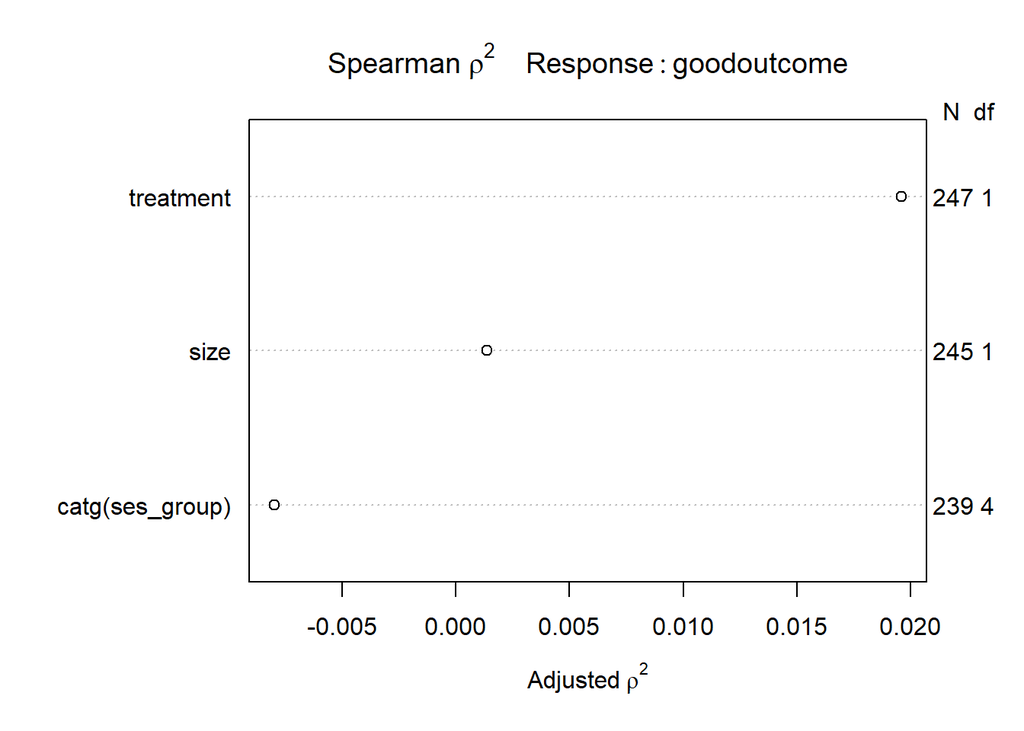

```r
plot(spearman2(goodoutcome ~ size + treatment +
                   catg(ses_group), data = dat10))
```

Treatment is the most promising variable, and is binary. Size is next, which is quantitative, so it looks like adding a treatment-size interaction is the most promising way to spend a single additional degree of freedom.

# 13 Question 13

Using the data from Question 10, identify how many subjects are missing data in at least one variable. Are there any missing outcome data? How do you know?

## 13.1 Answer 13 (5 points)

```r
map_df(dat10, function(x) sum(is.na(x)))
```

```
# A tibble: 1 x 6
  subject outcome  size treatment ses_group goodoutcome
    <int>   <int> <int>     <int>     <int>       <int>
1       0       0     5         3        11           0
```

There are no missing data in the `goodoutcome` variable. But there are 5 missing `size`s, 3 missing `treatment`s and 11 missing `ses_group`s. So there could be as many as 19 subjects (5 + 3 + 11) with a missing value. But someone could be missing more than one variable. Is that the case? We know that’s it’s not, because our model in question 10 dropped only 18 observations.

```r
dat10 %>%
    filter(!complete.cases(.))
```

```
# A tibble: 18 x 6
   subject  outcome  size treatment ses_group goodoutcome
   <fct>    <fct>   <dbl> <lgl>         <int>       <dbl>
 1 ID-15101 Good    139.  FALSE            NA          1.
 2 ID-20994 Good     NA   TRUE             NA          1.
 3 ID-23659 Bad      NA   FALSE             1          0.
 4 ID-27063 Bad     105.  TRUE             NA          0.
 5 ID-40409 Bad      83.8 FALSE            NA          0.
 6 ID-46418 Good     75.8 FALSE            NA          1.
 7 ID-50010 Bad      NA   TRUE              5          0.
 8 ID-53848 Bad     111.  NA                1          0.
 9 ID-54448 Good    111.  FALSE            NA          1.
10 ID-56229 Bad     138.  TRUE             NA          0.
11 ID-64661 Good     92.4 TRUE             NA          1.
12 ID-67155 Bad     143.  TRUE             NA          0.
13 ID-69041 Bad      NA   TRUE              5          0.
14 ID-78586 Good    112.  NA                3          1.
15 ID-79751 Bad     129.  FALSE            NA          0.
16 ID-91691 Bad     124.  NA                1          0.
17 ID-92839 Good     63.1 FALSE            NA          1.
18 ID-96388 Good     NA   FALSE             5          1.
```

One subject (`ID-20994`) is missing both `size` and `ses_group`, so there are 18 subjects with at least one missing value.

# 14 Question 14

Using the data from Question 10, fit the model you specified in Question 12 (including the non-linear term), while also accounting for missing data using **multiple imputation**. Set your seed to be `432432`, and impute the predictors that need imputation using all available observations on all available variables.

Specify the code you used to fit your imputation model and your outcome model, specify the resulting fitted outcome model in terms of odds ratio estimates and a nomogram, and then write a few English sentences describing how the addition of imputation and a non-linear term changes (or doesn’t change) the conclusions from what we saw in the `m1` model in Questions 10 and 11.

## 14.1 Answer 14 (15 points)

Here is the imputation model that I fit. I chose parameters here that seemed popular among the people doing the assignment, probably because it mirrors the approach in Chapter 15 of the Course Notes.

```r
d <- datadist(dat10)
options(datadist = "d")

imp_14 <- aregImpute(~ goodoutcome + size +
                         catg(treatment) + catg(ses_group),
                     nk = c(0, 3),
                     tlinear = TRUE, data = dat10, B = 10,
                     n.impute = 20, pr = FALSE)
```

Now, let’s fit the actual logistic regression model, with multiple imputation.

```r
d <- datadist(dat10)
options(datadist = "d")

(mod14 <- fit.mult.impute(goodoutcome ~
                             size * catg(treatment) +
                             catg(ses_group),
                         fitter = lrm, xtrans = imp_14,
                         data = dat10, x = TRUE, y = TRUE))
```

```
Variance Inflation Factors Due to Imputation:

            Intercept                  size        treatment=TRUE
                 1.04                  1.02                  1.02
          ses_group=2           ses_group=3           ses_group=4
                 1.12                  1.14                  1.13
          ses_group=5 size * treatment=TRUE
                 1.18                  1.02

Rate of Missing Information:

            Intercept                  size        treatment=TRUE
                 0.04                  0.02                  0.02
          ses_group=2           ses_group=3           ses_group=4
                 0.11                  0.13                  0.12
          ses_group=5 size * treatment=TRUE
                 0.15                  0.02

d.f. for t-distribution for Tests of Single Coefficients:

            Intercept                  size        treatment=TRUE
             13010.07              70568.21              42102.41
          ses_group=2           ses_group=3           ses_group=4
              1620.28               1202.76               1431.19
          ses_group=5 size * treatment=TRUE
               817.48              51299.84

The following fit components were averaged over the 20 model fits:

  stats linear.predictors
```

```
Logistic Regression Model

 fit.mult.impute(formula = goodoutcome ~ size * catg(treatment) +
     catg(ses_group), fitter = lrm, xtrans = imp_14, data = dat10,
     x = TRUE, y = TRUE)

                      Model Likelihood     Discrimination    Rank Discrim.
                         Ratio Test           Indexes           Indexes
 Obs           250    LR chi2      8.96    R2       0.049    C       0.614
  0            170    d.f.            7    g        0.482    Dxy     0.227
  1             80    Pr(> chi2) 0.2586    gr       1.620    gamma   0.228
 max |deriv| 3e-09                         gp       0.100    tau-a   0.099
                                           Brier    0.210

                       Coef    S.E.   Wald Z Pr(>|Z|)
 Intercept             -1.0215 1.0879 -0.94  0.3477
 size                   0.0019 0.0084  0.22  0.8245
 treatment=TRUE        -1.5154 1.3770 -1.10  0.2711
 ses_group=2            0.3743 0.6032  0.62  0.5349
 ses_group=3            0.5099 0.5258  0.97  0.3321
 ses_group=4            0.3515 0.5628  0.62  0.5323
 ses_group=5            0.4857 0.5190  0.94  0.3494
 size * treatment=TRUE  0.0076 0.0114  0.67  0.5031
```

The treatment effect, which was borderline significant in the original model, is not quite significant in the ANOVA table for this model with imputation and an interaction term.

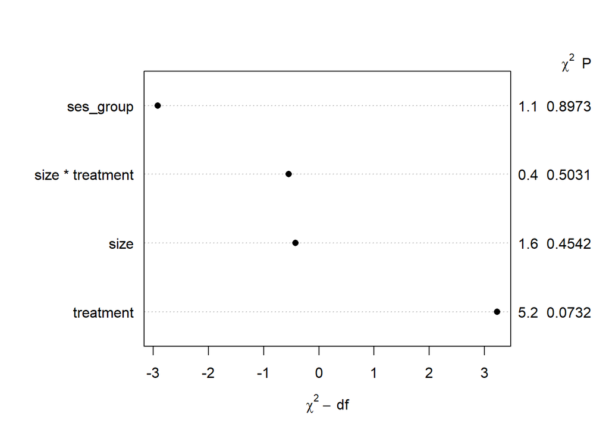

```r
plot(anova(mod14))
```

Here are the odds ratio estimates and nomogram, as requested.

```r
summary(mod14)
```

```
             Effects              Response : goodoutcome

 Factor                 Low   High  Diff. Effect    S.E.    Lower 0.95
 size                   100.5 135.5 35     0.065235 0.29424 -0.51147
  Odds Ratio            100.5 135.5 35     1.067400      NA  0.59962
 treatment - TRUE:FALSE   1.0   2.0 NA    -0.644380 0.28414 -1.20130
  Odds Ratio              1.0   2.0 NA     0.524990      NA  0.30081
 ses_group - 1:3          3.0   1.0 NA    -0.509900 0.52576 -1.54040
  Odds Ratio              3.0   1.0 NA     0.600560      NA  0.21430
 ses_group - 2:3          3.0   2.0 NA    -0.135610 0.49596 -1.10770
  Odds Ratio              3.0   2.0 NA     0.873180      NA  0.33032
 ses_group - 4:3          3.0   4.0 NA    -0.158390 0.44193 -1.02460
  Odds Ratio              3.0   4.0 NA     0.853520      NA  0.35895
 ses_group - 5:3          3.0   5.0 NA    -0.024194 0.37472 -0.75863
  Odds Ratio              3.0   5.0 NA     0.976100      NA  0.46831
 Upper 0.95
  0.641940
  1.900200
 -0.087481
  0.916240
  0.520570
  1.683000
  0.836460
  2.308200
  0.707780
  2.029500
  0.710240
  2.034500

Adjusted to: size=114.3 treatment=FALSE
```

The odds ratio for treatment is significant at the 5% level in this summary, holding everything else constant, but this is wrapped up in the interaction term.

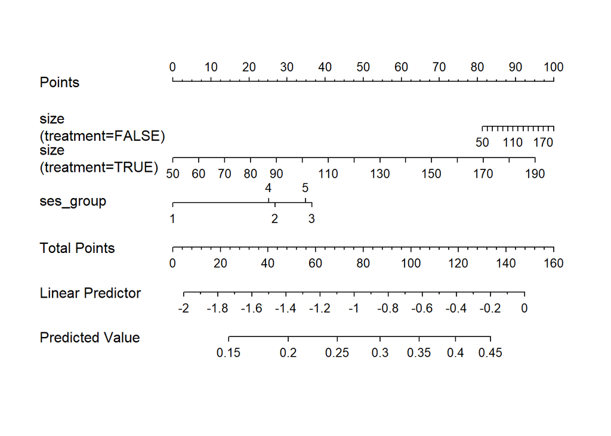

```r
plot(nomogram(mod14, fun = plogis))
```

In this model post-imputation. it looks like the impact of size for those without the treatment is much more modest than the impact of size when the treatment is received, according to the nomogram.